# DSA2101 Group Project

Yixuan, Sandrina, Michelle, Melisa, Salman

2024-11-15

# What trends can be observed in the evolution of musical characteristics across Taylor Swift’s various albums over time?

# Introduction

With the release of *The Eras Tour* film, the “taylor” R package curated by W. Jake Thompson provides an in-depth view of Taylor Swift’s discography, featuring lyrics and audio characteristics data sourced from Genius and Spotify APIs. It includes three main datasets: “taylor_album_songs,” featuring all tracks from her official studio albums while excluding standalone singles and original album versions replaced by *Taylor’s Version*; “taylor_all_songs,” which covers her entire discography, including EPs, individual singles, and re-releases; and “taylor_albums,” summarising her album release history.

These datasets present a unique opportunity to explore Swift’s music on multiple levels, from lyrical themes to evolving audio characteristics. Each dataset includes many features, allowing in-depth analyses of her stylistic shifts and emotional tones across albums. Through this report, we aim to investigate how Swift’s music has evolved across albums over time, considering factors like energy, loudness, speechiness, acousticness, instrumentalness, liveness, valence, tempo, and danceability. This exploration will help us understand the patterns within her discography and the elements that make her music resonate deeply with her audience.

# Data Cleaning and Summary

To begin, we conducted data cleaning across three primary datasets: “taylor_album_songs”, “taylor_all_songs”, “and taylor_albums”. Despite some missing values, we retained these entries to preserve the integrity and completeness of the dataset. For example, a missing value under the “featuring” column signifies a solo performance by Taylor Swift, not incomplete or unreliable data. Next, we examined the uniqueness of each dataset, which was essential before merging. Uniqueness was established based on “track_name” for both “taylor_album_songs” and “taylor_all_songs”, while “album_name” ensured uniqueness for “taylor_albums”. All rows were unique in each dataset except for “taylor_all_songs”, where the track “I’m Only Me When I’m With You” appears twice. Further examination confirmed that this track exists on two different albums.

We also compared album names across datasets to identify any inconsistencies. Using an anti-join operation, we identified that the albums Beautiful Eyes, Fearless, Red, and The Taylor Swift Holiday Collection are missing from taylor_album_songs. Additionally, songs with missing album names are confirmed as non-album tracks, such as soundtracks or singles. For songs in the Beautiful Eyes album, which had incomplete entries, we utilised available metadata (such as the “artist” column) to update missing values, ensuring consistency with other records by assigning “Taylor Swift” to the missing artist entries. Lastly, we merged “taylor_album_songs” with “taylor_albums” using a left join on the “album_name” column. This approach allowed us to retain all essential album information while focusing on tracks within Swift’s albums, which aligns with the objective of this report. With this final join, the dataset was structured and prepared for visual analysis.

### Reading the data

```r
# install.packages("tidytuesdayR")

tuesdata <- tidytuesdayR::tt_load('2023-10-17')

taylor_album_songs <- tuesdata$taylor_album_songs
taylor_all_songs <- tuesdata$taylor_all_songs
taylor_albums <- tuesdata$taylor_albums
```

### Checking the features of data

```r
glimpse(taylor_album_songs)
```

```
## Rows: 194
## Columns: 29
## $ album_name          <chr> "Taylor Swift", "Taylor Swift", "Taylor Swift", "T…
## $ ep                  <lgl> FALSE, FALSE, FALSE, FALSE, FALSE, FALSE, FALSE, F…
## $ album_release       <date> 2006-10-24, 2006-10-24, 2006-10-24, 2006-10-24, 2…
## $ track_number        <dbl> 1, 2, 3, 4, 5, 6, 7, 8, 9, 10, 11, 12, 13, 14, 15,…
## $ track_name          <chr> "Tim McGraw", "Picture To Burn", "Teardrops On My …
## $ artist              <chr> "Taylor Swift", "Taylor Swift", "Taylor Swift", "T…
## $ featuring           <chr> NA, NA, NA, NA, NA, NA, NA, NA, NA, NA, NA, NA, NA…
## $ bonus_track         <lgl> FALSE, FALSE, FALSE, FALSE, FALSE, FALSE, FALSE, F…
## $ promotional_release <date> NA, NA, NA, NA, NA, NA, NA, NA, NA, NA, NA, NA, N…
## $ single_release      <date> 2006-06-19, 2008-02-03, 2007-02-19, NA, NA, NA, N…
## $ track_release       <date> 2006-06-19, 2006-10-24, 2006-10-24, 2006-10-24, 2…
## $ danceability        <dbl> 0.580, 0.658, 0.621, 0.576, 0.418, 0.589, 0.479, 0…
## $ energy              <dbl> 0.491, 0.877, 0.417, 0.777, 0.482, 0.805, 0.578, 0…
```

[output cut: 16 more lines]

```r
glimpse(taylor_all_songs)
```

```
## Rows: 274
## Columns: 29
## $ album_name          <chr> "Taylor Swift", "Taylor Swift", "Taylor Swift", "T…
## $ ep                  <lgl> FALSE, FALSE, FALSE, FALSE, FALSE, FALSE, FALSE, F…
## $ album_release       <date> 2006-10-24, 2006-10-24, 2006-10-24, 2006-10-24, 2…
## $ track_number        <dbl> 1, 2, 3, 4, 5, 6, 7, 8, 9, 10, 11, 12, 13, 14, 15,…
## $ track_name          <chr> "Tim McGraw", "Picture To Burn", "Teardrops On My …
## $ artist              <chr> "Taylor Swift", "Taylor Swift", "Taylor Swift", "T…
## $ featuring           <chr> NA, NA, NA, NA, NA, NA, NA, NA, NA, NA, NA, NA, NA…
## $ bonus_track         <lgl> FALSE, FALSE, FALSE, FALSE, FALSE, FALSE, FALSE, F…
## $ promotional_release <date> NA, NA, NA, NA, NA, NA, NA, NA, NA, NA, NA, NA, N…
## $ single_release      <date> 2006-06-19, 2008-02-03, 2007-02-19, NA, NA, NA, N…
## $ track_release       <date> 2006-06-19, 2006-10-24, 2006-10-24, 2006-10-24, 2…
## $ danceability        <dbl> 0.580, 0.658, 0.621, 0.576, 0.418, 0.589, 0.479, 0…
## $ energy              <dbl> 0.491, 0.877, 0.417, 0.777, 0.482, 0.805, 0.578, 0…
```

[output cut: 16 more lines]

```r
glimpse(taylor_albums)
```

```
## Rows: 14
## Columns: 5
## $ album_name       <chr> "Taylor Swift", "The Taylor Swift Holiday Collection"…
## $ ep               <lgl> FALSE, TRUE, TRUE, FALSE, FALSE, FALSE, FALSE, FALSE,…
## $ album_release    <date> 2006-10-24, 2007-10-14, 2008-07-15, 2008-11-11, 2010…
## $ metacritic_score <dbl> 67, NA, NA, 73, 77, 77, 76, 71, 79, 88, 85, 82, 91, 85
## $ user_score       <dbl> 8.5, NA, NA, 8.4, 8.6, 8.5, 8.2, 8.3, 8.4, 9.0, 8.9, …
```

### Checking albums

```r
# Checking the number of albums in each dataset
taylor_album_songs %>% count(album_name)
```

```
## # A tibble: 10 × 2
##    album_name                      n
##    <chr>                       <int>
##  1 1989                           16
##  2 Fearless (Taylor's Version)    26
##  3 Lover                          18
##  4 Midnights                      23
##  5 Red (Taylor's Version)         30
##  6 Speak Now                      17
##  7 Taylor Swift                   15
##  8 evermore                       17
##  9 folklore                       17
## 10 reputation                     15
```

```r
taylor_all_songs %>% count(album_name)
```

```
## # A tibble: 15 × 2
##    album_name                              n
##    <chr>                               <int>
##  1 1989                                   16
##  2 Beautiful Eyes                          6
##  3 Fearless                               19
##  4 Fearless (Taylor's Version)            26
##  5 Lover                                  18
##  6 Midnights                              23
##  7 Red                                    22
##  8 Red (Taylor's Version)                 30
##  9 Speak Now                              17
## 10 Taylor Swift                           15
## 11 The Taylor Swift Holiday Collection     6
## 12 evermore                               17
## 13 folklore                               17
## 14 reputation                             15
## 15 <NA>                                   27
```

```r
# Anti-join to check which albums occur in one of the datasets only
anti_join(taylor_all_songs, taylor_album_songs, by = "album_name")
```

```
## # A tibble: 80 × 29
##    album_name ep    album_release track_number track_name       artist featuring
##    <chr>      <lgl> <date>               <dbl> <chr>            <chr>  <chr>
##  1 Fearless   FALSE 2008-11-11               1 Fearless         Taylo… <NA>
##  2 Fearless   FALSE 2008-11-11               2 Fifteen          Taylo… <NA>
##  3 Fearless   FALSE 2008-11-11               3 Love Story       Taylo… <NA>
##  4 Fearless   FALSE 2008-11-11               4 Hey Stephen      Taylo… <NA>
##  5 Fearless   FALSE 2008-11-11               5 White Horse      Taylo… <NA>
##  6 Fearless   FALSE 2008-11-11               6 You Belong With… Taylo… <NA>
##  7 Fearless   FALSE 2008-11-11               7 Breathe          Taylo… Colbie C…
##  8 Fearless   FALSE 2008-11-11               8 Tell Me Why      Taylo… <NA>
##  9 Fearless   FALSE 2008-11-11               9 You're Not Sorry Taylo… <NA>
## 10 Fearless   FALSE 2008-11-11              10 The Way I Loved… Taylo… <NA>
## # ℹ 70 more rows
## # ℹ 22 more variables: bonus_track <lgl>, promotional_release <date>,
## #   single_release <date>, track_release <date>, danceability <dbl>,
## #   energy <dbl>, key <dbl>, loudness <dbl>, mode <dbl>, speechiness <dbl>,
## #   acousticness <dbl>, instrumentalness <dbl>, liveness <dbl>, valence <dbl>,
## #   tempo <dbl>, time_signature <dbl>, duration_ms <dbl>, explicit <lgl>,
## #   key_name <chr>, mode_name <chr>, key_mode <chr>, lyrics <lgl>
```

```r
anti_join(taylor_all_songs, taylor_album_songs, by = "album_name") %>% count(album_name)
```

```
## # A tibble: 5 × 2
##   album_name                              n
##   <chr>                               <int>
## 1 Beautiful Eyes                          6
## 2 Fearless                               19
## 3 Red                                    22
## 4 The Taylor Swift Holiday Collection     6
## 5 <NA>                                   27
```

```r
# album_name Beautiful Eyes, Fearless, Red, and The Taylor Swift Holiday Collection are not in taylor_album_songs
# songs with album_name=NA means that the songs are not in any album
# songs in Beautiful Eyes have a lot of missing data
```

### Checking duplicate rows

```r
taylor_album_songs %>% count(track_name) %>% filter(n > 1)
```

```
## # A tibble: 0 × 2
## # ℹ 2 variables: track_name <chr>, n <int>
```

```r
taylor_all_songs %>% count(track_name) %>% filter(n > 1)
```

```
## # A tibble: 1 × 2
##   track_name                        n
##   <chr>                         <int>
## 1 I'm Only Me When I'm With You     2
```

```r
# the song appears in Taylor Swift and Beautiful Eyes album but with different years
taylor_all_songs %>% filter(track_name %in% "I'm Only Me When I'm With You")
```

```
## # A tibble: 2 × 29
##   album_name     ep    album_release track_number track_name    artist featuring
##   <chr>          <lgl> <date>               <dbl> <chr>         <chr>  <chr>
## 1 Taylor Swift   FALSE 2006-10-24              12 I'm Only Me … Taylo… <NA>
## 2 Beautiful Eyes TRUE  2008-07-15               5 I'm Only Me … <NA>   <NA>
## # ℹ 22 more variables: bonus_track <lgl>, promotional_release <date>,
## #   single_release <date>, track_release <date>, danceability <dbl>,
## #   energy <dbl>, key <dbl>, loudness <dbl>, mode <dbl>, speechiness <dbl>,
## #   acousticness <dbl>, instrumentalness <dbl>, liveness <dbl>, valence <dbl>,
## #   tempo <dbl>, time_signature <dbl>, duration_ms <dbl>, explicit <lgl>,
## #   key_name <chr>, mode_name <chr>, key_mode <chr>, lyrics <lgl>
```

### Handling missing data

```r
# Change artist = NA to artist = "Taylor Swift" in taylor_all_songs, for album_name = Beautiful Eyes
taylor_all_songs$artist <- ifelse(taylor_all_songs$album_name == "Beautiful Eyes",
                                  "Taylor Swift", taylor_all_songs$artist)
```

### Joining dataset

```r
# Joining by album for taylor_album_songs and taylor_albums
album <- left_join(taylor_album_songs, taylor_albums, by = "album_name") %>%
  select(album_name, ep = ep.x, album_release = album_release.x, track_number, track_name,
         artist, featuring, bonus_track, single_release, track_release, danceability,
         energy, key, loudness, mode, speechiness, acousticness, instrumentalness,
         liveness, valence, tempo, time_signature, duration_ms, explicit, key_name,
         mode_name, key_mode, metacritic_score, user_score)
glimpse(album)
```

```
## Rows: 194
## Columns: 29
## $ album_name       <chr> "Taylor Swift", "Taylor Swift", "Taylor Swift", "Tayl…
## $ ep               <lgl> FALSE, FALSE, FALSE, FALSE, FALSE, FALSE, FALSE, FALS…
## $ album_release    <date> 2006-10-24, 2006-10-24, 2006-10-24, 2006-10-24, 2006…
## $ track_number     <dbl> 1, 2, 3, 4, 5, 6, 7, 8, 9, 10, 11, 12, 13, 14, 15, 1,…
## $ track_name       <chr> "Tim McGraw", "Picture To Burn", "Teardrops On My Gui…
## $ artist           <chr> "Taylor Swift", "Taylor Swift", "Taylor Swift", "Tayl…
## $ featuring        <chr> NA, NA, NA, NA, NA, NA, NA, NA, NA, NA, NA, NA, NA, N…
## $ bonus_track      <lgl> FALSE, FALSE, FALSE, FALSE, FALSE, FALSE, FALSE, FALS…
## $ single_release   <date> 2006-06-19, 2008-02-03, 2007-02-19, NA, NA, NA, NA, …
## $ track_release    <date> 2006-06-19, 2006-10-24, 2006-10-24, 2006-10-24, 2006…
## $ danceability     <dbl> 0.580, 0.658, 0.621, 0.576, 0.418, 0.589, 0.479, 0.59…
## $ energy           <dbl> 0.491, 0.877, 0.417, 0.777, 0.482, 0.805, 0.578, 0.62…
## $ key              <dbl> 0, 7, 10, 9, 5, 5, 2, 8, 4, 2, 2, 8, 7, 4, 10, 5, 7, …
```

[output cut: 16 more lines]

### See the correlation between each feature

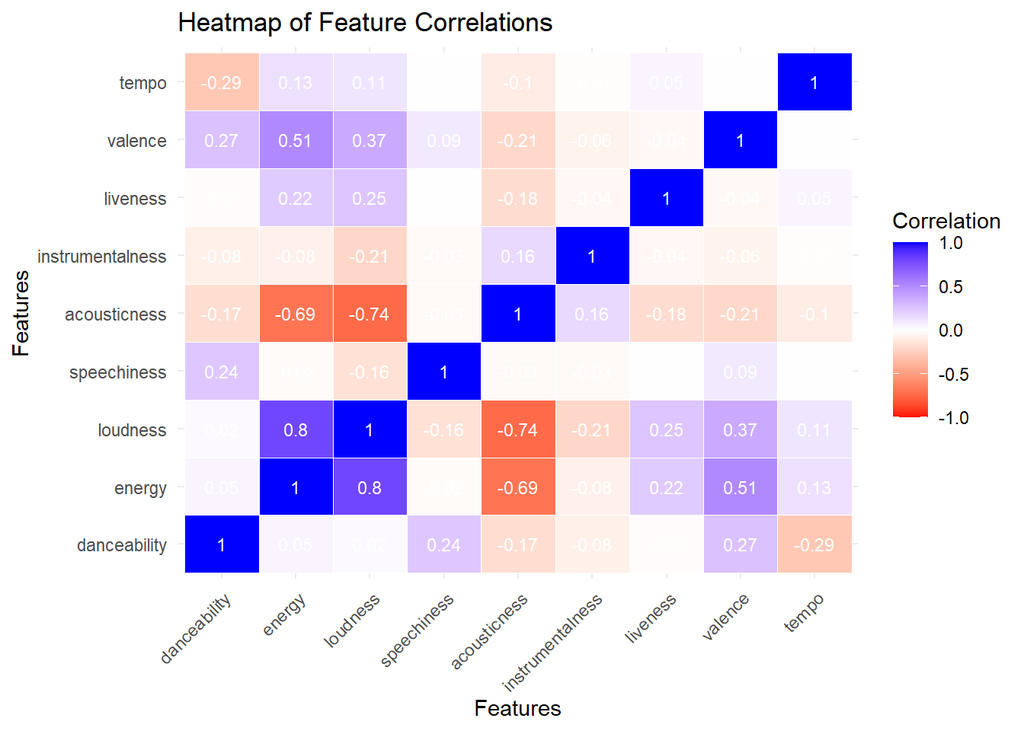

```r
# Select only numerical features for correlation analysis
numeric_features <- album %>%
  select(danceability, energy, loudness, speechiness, acousticness, instrumentalness,
         liveness, valence, tempo)

# Compute the correlation matrix
cor_matrix <- cor(numeric_features, use = "complete.obs")

# Melt the correlation matrix into long format for ggplot2
melted_cor_matrix <- melt(cor_matrix)

# Create a heatmap using ggplot2 with a red-blue colour palette
ggplot(melted_cor_matrix, aes(x = Var1, y = Var2, fill = value)) +
  geom_tile(color = "white") +
  scale_fill_gradient2(low = "red", mid = "white", high = "blue",
                       midpoint = 0, limit = c(-1, 1),
                       space = "Lab", name="Correlation") +  # Red for negative, blue for positive
  geom_text(aes(label = round(value, 2)), color = "white", size = 3) +  # Add correlation values as text
  labs(title = "Heatmap of Feature Correlations",
       x = "Features",
       y = "Features",
       fill = "Correlation") +
  theme_minimal() +
  theme(axis.text.x = element_text(angle = 45, vjust = 1, hjust = 1))
```

# Visualisation

### Energy vs Loudness by Year Group Scatter Plot

Based on the heatmap analysis, we observed a relatively high correlation between the loudness and energy features compared to other musical characteristics. This finding prompted us to explore how this correlation between loudness and energy has evolved over different periods in Taylor Swift’s career. By grouping the data into distinct year intervals, we aimed to uncover any potential shifts in the relationship between these two features across her discography. Our analysis uses scatter plots with LOESS trendlines and correlation coefficients to visualise and quantify this relationship over time. This approach allows us to detect changes in the intensity and dynamism of her music, as loudness reflects volume while energy captures the overall activity level of a track.

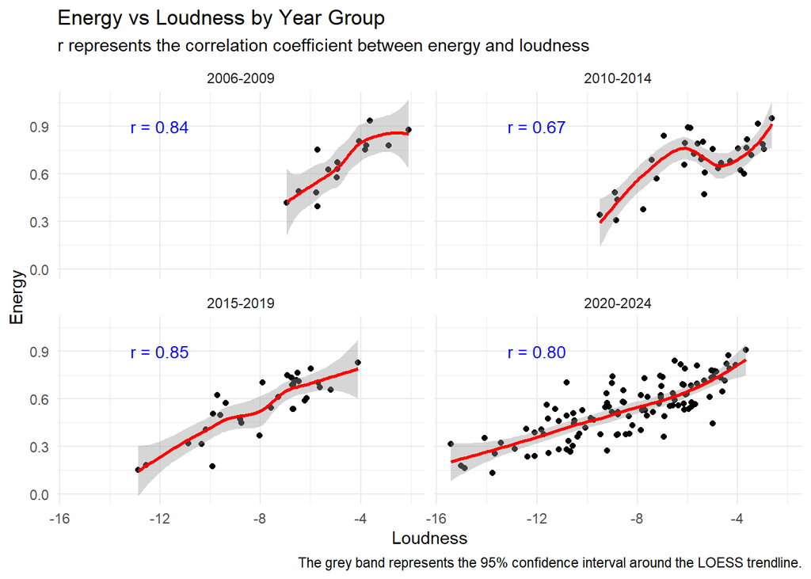

```r
# Convert track_release to Date format and extract the year
album$track_release <- as.Date(album$track_release)
album$year_group <- cut(album$track_release,
                        breaks = as.Date(c("2005-01-01", "2010-01-01", "2015-01-01", "2020-01-01", "2025-01-01")),
                        labels = c("2006-2009", "2010-2014", "2015-2019", "2020-2024"))

# Function to calculate the correlation coefficient for each year group
get_correlation <- function(album, x, y) {
  album %>%
    group_by(year_group) %>%
    summarize(correlation = round(cor(.data[[x]], .data[[y]], use = "complete.obs"), 2))
}

# Calculate correlation coefficients for energy vs loudness
correlations <- get_correlation(album, "loudness", "energy")

# Merge correlations back into the original data
album <- merge(album, correlations, by = "year_group")

# Create a scatter plot with LOESS lines and 95% confidence intervals for energy vs loudness
ggplot(album, aes(x = loudness, y = energy)) +
  geom_point() +
  geom_smooth(method = "loess", se = TRUE, color = "red") +
  facet_wrap(~ year_group) +

  # Add correlation coefficient as a text annotation for each year group
  geom_text(data = correlations, aes(label = sprintf("r = %.2f", correlation), x = -12, y = 0.9),
            inherit.aes = FALSE, size = 3.7, color = "blue") +
  labs(title = "Energy vs Loudness by Year Group",
       subtitle = "r represents the correlation coefficient between energy and loudness",
       x = "Loudness",
       y = "Energy",
       caption = "The grey band represents the 95% confidence interval around the LOESS trendline.") +
  theme_minimal()
```

### Taylor Swift’s Musical Key Evolution Keyboard Heatmap

This visualisation uses an animated keyboard plot to showcase the distribution of Taylor Swift’s songs by musical key across her album releases. Each key on the piano keyboard (with both white keys—C, D, E, F, G, A, B—and black keys—C#, D#, F#, G#, A#—positioned as they appear on a traditional piano) represents a different musical key. The plot dynamically displays the percentage of Taylor Swift’s songs in each key, with a colour gradient applied to the keys to indicate the proportion of songs in that key for each album. As the animation progresses through Taylor Swift’s discography, viewers can observe how her choice of musical keys has evolved over time with each album release. This visualisation is particularly effective because the familiar keyboard layout intuitively represents the concept of musical keys, making it easy to see which keys are most prevalent in her music at any given time. The colour gradient further enhances the clarity by visually representing the percentage of songs in each key, offering a deeper insight into the stylistic shifts in her music. By animating the plot across her albums, we can track how the distribution of keys has changed. This shift in the use of musical keys could reflect changes in the mood, tone, or style of her music over time, providing valuable insights into how Taylor Swift’s musical preferences and sound have developed throughout her career.

```r
# Create a unique album_names data frame with the album name and modified album release date
album_names <- album %>%
  select(album_name, album_release) %>%
  unique() %>%
  mutate(album_release_name = paste(album_release, album_name, sep = " - "))  # Combine date and album name

# Calculate the percentage of songs by key
key_distribution <- album %>%
  group_by(key_name, album_release) %>%
  summarize(count = n()) %>%
  mutate(percentage = (count / sum(count, na.rm = TRUE)) * 100) %>%
  na.omit()

# Join modified album names with key distribution
key_distribution <- left_join(key_distribution, album_names, by = "album_release") %>%
  select(-album_release) %>%
  rename(album_release = album_release_name)


# Define the positions for white and black keys on a piano
white_keys <- c("C", "D", "E", "F", "G", "A", "B")
black_keys <- c("C#", "D#", "F#", "G#", "A#")

# Define positions for keys on the keyboard (x-axis)
key_positions <- data.frame(
  key_name = c(white_keys, black_keys),
  position = c(1, 2, 3, 4, 5, 6, 7, 1.5, 2.5, 4.5, 5.5, 6.5) # Black keys centered between white keys
)

dfcur <- NULL
for (y in sort(unique(key_distribution$album_release))){
  temp = key_distribution %>%
    filter(album_release == y) %>%
    full_join(key_positions,  by = "key_name") %>%
    replace_na(list(count = 0, percentage = 0))
  temp$album_release = y
  dfcur <- rbind(dfcur, temp)
}
dfcur$album_release = factor(dfcur$album_release, ordered = T,
                             levels = sort(unique(dfcur$album_release)))
key_distribution <- dfcur

# Create a custom keyboard plot
animated_plot <- ggplot() +

  # White keys (rectangles side by side with no gaps)
  geom_rect(data = key_distribution %>% filter(key_name %in% white_keys),
            aes(xmin = position - 0.5, xmax = position + 0.5,
                ymin = -0.3, ymax = 0.8), fill = "#FFFFFF", color = "#000000") +

  # Black keys (rectangles centred on top of white keys)
  geom_rect(data = key_distribution %>% filter(key_name %in% black_keys),
            aes(xmin = position - 0.25, xmax = position + 0.25,
                ymin = 0.1, ymax = 0.8), fill = "#000000") +

  # Add text labels for white keys with gradient colour based on percentage and white text
  geom_label(data = key_distribution %>% filter(key_name %in% white_keys),
             aes(x = position, y = -0.5,
                 label = key_name,
                 fill = percentage), color = "#FFFFFF", size = 6.7) + # White text for contrast

  # Add text labels for black keys with gradient colour based on percentage and black text
  geom_label(data = key_distribution %>% filter(key_name %in% black_keys),
             aes(x = position, y = 0.325,
                 label = key_name,
                 fill = percentage), color = "#000000", size = 6) + # Black text for contrast

  # Use viridis colour scale for percentage gradient
  scale_fill_viridis_c(option = "plasma", direction = -1) +

  # Adjust plot limits and remove axis labels/ticks to resemble a keyboard
  scale_y_continuous(limits = c(-2, NA)) +

  # Dynamically update the title using glue for each frame
  labs(title = "Taylor Swift's Musical Key Evolution", subtitle = "{closest_state} - Percentage of Songs by Key",
       x = NULL,
       y = NULL,
       fill = "% of Songs") +

  theme_void() +   # Remove axis lines and ticks
  theme(legend.position="top") +

  # Animate over album_release
  transition_states(album_release) +
  enter_fade() + exit_fly(y_loc = 1)

# Save the animation as a GIF
animate(animated_plot, duration = 10, fps = 1, renderer = av_renderer())
```

[video not shown]

### Taylor Swift’s Top 2 and Bottom 2 Albums Musical Feature Distribution Radar Chart

The radar chart in this visualisation allows us to compare key musical features (e.g., danceability, energy, loudness, speechiness, acousticness, instrumentalness, liveness, valence, and tempo) across Taylor Swift’s top and bottom albums based on critical and user ratings. By normalizing values like loudness and tempo, we normalize each feature on a scale from 0 to 1, making it easier to see variations across different dimensions for each album. Radar charts are useful here because they display multiple variables in a circular layout, making it straightforward to compare feature distributions and see which attributes are prominent or minimal in different albums. By including both top and low-ranked albums, the chart provides a clear visual representation of how musical attributes fluctuate.

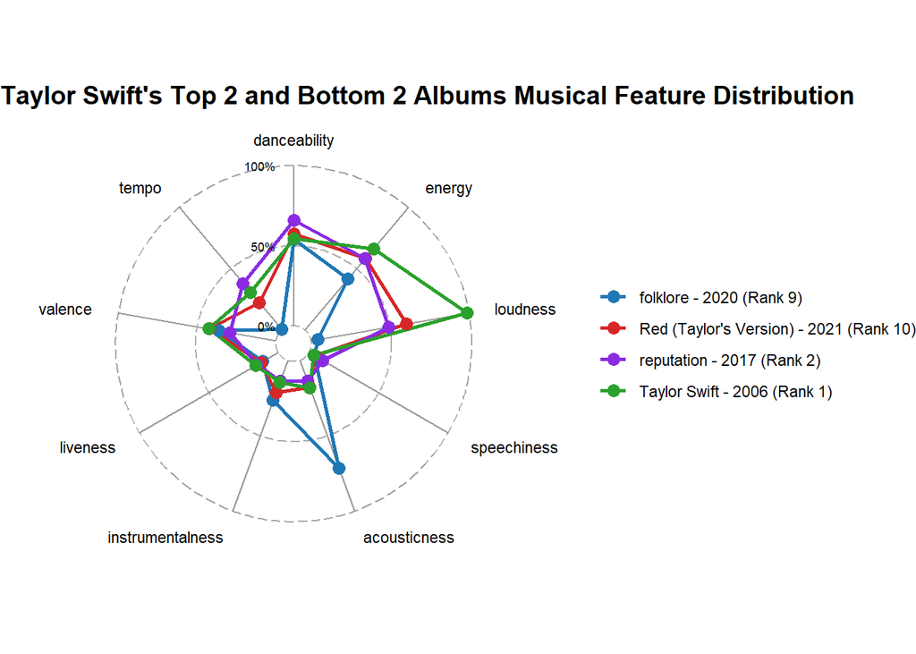

```r
# Aggregate the data by album, calculating the mean for each feature
album_data <- album %>%
  mutate(album_name = paste(album_name, "-", year(album_release))) %>%
  group_by(album_name) %>%
  select(-c(key,mode)) %>%
  summarize(
    metacritic = first(metacritic_score),
    user_score = first(user_score),
    across(danceability:tempo, function(x) mean(x, na.rm = TRUE))
  )

# Add Rank based on the average of metacritic and user_score
album_data <- album_data %>%
  mutate(
    avg_score = (metacritic + user_score*10) / 2,
    rank = ntile(avg_score, 10)
  ) %>%
  select(-avg_score, -metacritic, -user_score)

# Normalize loudness, tempo, and instrumentalness
album_data <- album_data %>%
  mutate(
    loudness = (loudness - min(loudness, na.rm = TRUE)) / (max(loudness, na.rm = TRUE) - min(loudness, na.rm = TRUE)),
    tempo = (tempo - min(tempo, na.rm = TRUE)) / (max(tempo, na.rm = TRUE) - min(tempo, na.rm = TRUE)),
    instrumentalness = -1/log(instrumentalness + 1e-6),
    instrumentalness = (instrumentalness - min(instrumentalness, na.rm = TRUE)) / (max(instrumentalness, na.rm = TRUE) - min(instrumentalness, na.rm = TRUE))
  )

# Add max and min rows for scaling in the radar chart
max_min <- data.frame(
  album_name = c("max", "min"),
  danceability = c(1, 0),
  energy = c(1, 0),
  loudness = c(1, 0),
  speechiness = c(1, 0),
  acousticness = c(1, 0),
  instrumentalness = c(1, 0),
  liveness = c(1, 0),
  valence = c(1, 0),
  tempo = c(1, 0)
)

# Combine max/min rows with album data
album_data <- bind_rows(max_min, album_data)

# Rename album_name to group for compatibility with ggradar
album_data <- album_data %>%
  rename(group = album_name)

# Filter top 2 and bottom 2 albums based on rank
top_2 <- album_data %>% slice_min(order_by = rank, n = 2)
bottom_2 <- album_data %>% slice_max(order_by = rank, n = 2)

# Combine the top 2 and bottom 2 albums
selected_albums <- bind_rows(top_2, bottom_2)

# Modify album names to include rank
selected_albums <- selected_albums %>%
  mutate(group = paste0(group, " (Rank ", rank, ")"))

# Remove the rank column before plotting
selected_albums <- selected_albums %>% select(-rank)

# Define a colour palette for the selected albums
palette_colors <- c("#1f77b4", "#d62728", "#8A2BE2", "#2ca02c")

# Plot the radar chart for all selected albums in a single chart
ggradar(selected_albums,
        axis.label.size = 3,
        grid.label.size = 3,
        group.point.size = 3,
        group.line.width = 1,
        background.circle.colour = "white",
        axis.line.colour = "gray60",
        gridline.min.colour = "gray60",
        gridline.mid.colour = "gray60",
        gridline.max.colour = "gray60",
        group.colours = palette_colors,
        plot.legend = TRUE) +
  ggtitle("Taylor Swift's Top 2 and Bottom 2 Albums Musical Feature Distribution") +
  theme_minimal() +
  theme_void() +
  theme(
    plot.title = element_text(size = 14, face = "bold"),
    legend.title = element_blank()
  )
```

# Discussion

### Taylor Swift’s Musical Key Evolution Keyboard Heatmap

This animated keyboard plot visualises the distribution of musical keys across Taylor Swift’s albums. Each piano key represents a different musical key, with a colour gradient highlighting the percentage of songs in that key per album. As the animation progresses, viewers can observe how Taylor’s choice of keys evolves, suggesting shifts in mood, tone, and style over time. Early albums, like Taylor Swift and Speak Now, feature keys such as G# and A# Major, capturing youthful optimism and emotional discovery. As her music matures in 1989 and Reputation, she moves into keys like D# and A Major, adding emotional depth, tension, and triumph as she navigates fame and self-reflection. Folklore and evermore mark a shift toward introspective storytelling, using a broader range of keys to explore themes of nostalgia and bittersweet triumph—particularly with F# Major in evermore, which underscores resilience and growth. In Lover, B Major introduces joy and hope, while Fearless (Taylor’s Version) revisits keys like F# Major and G Major to blend past and present emotions of love and empowerment. With Midnights, G# Major returns, now with a mature, introspective tone. These choices illustrate Swift’s artistic evolution, using keys as emotional markers that add depth to her themes of growth, heartbreak, and personal empowerment over time.

# Teamwork

As the primary focus of this project is on the three visualisations, we divided the coding tasks as follows:

1. **Scatter Plot**: Melisa and Muhammad Salman
2. **Keyboard Heatmap**: Yixuan
3. **Radar Chart**: Michelle and Sandrina

For the written report, Michelle was responsible for the introduction, and Melissa covered the data cleaning process. The other three team members would each write the discussion for their assigned visualisations.

# References

1. https://github.com/rfordatascience/tidytuesday/blob/master/data/2023/2023-10-17/readme.md
2. https://gganimate.com/
3. https://github.com/ricardo-bion/ggradar